# Collaborating in a Repository: READy Workflow Assignment

Author

Talia Swanson, Aylla Ermland

# 1 Methods

We used a dataset based on exampledata2.xlsx, which included the original raw data plus two new variables we added: one numeric and one categorical. The raw variables were (height, weight, and gender) to which we added daily step and stress levels as new variable. The data were cleaned by removing or correcting entry errors, converting variables to the correct type (numeric or factor), and dropping missing or inconsistent values to produce a clean dataset saved for reproducible analysis. A simple analysis of the five variables was conducted with exploratory plots, boxplots and scatterplots, to visualize the new added variables. Finally, a linear regression model was fitted with height as the outcome and the two new variables (daily steps and stress) as predictors.

## 1.1 Statistical analysis

# 2 Results

## 2.1 Exploratory/Descriptive analysis

## 2.2 Basic statistical analysis

### 2.2.1 Height Distribution

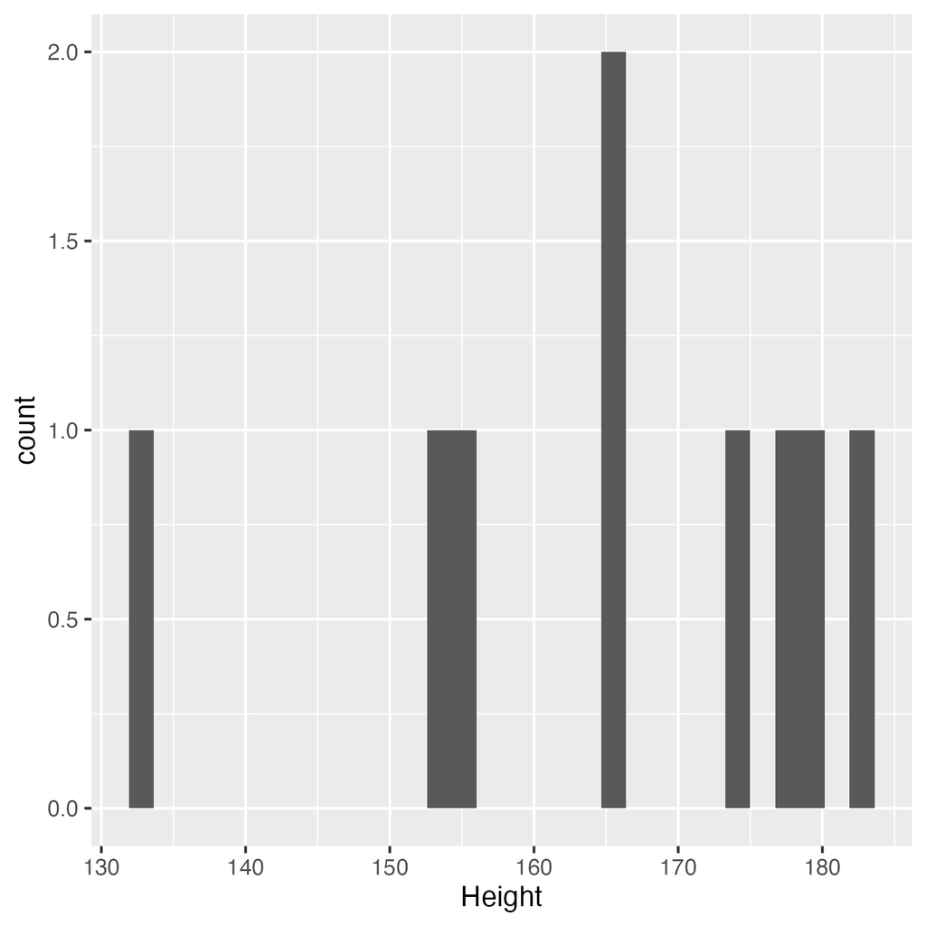

```r
##| label: fig-height-distribution
#| fig-cap: "Distribution of Height."
#| echo: FALSE
knitr::include_graphics(here("results","figures","height-distribution.png"))
```

### 2.2.2 Height by Gender and Weight

Figure 1 displays the relationship between height and weight stratified by gender. Both females and males have a general psotiive association between these variables, wtih height increasing as weight increases. However, there are multiple outliers within the male participants of the data set, which could be affected the assocaiion between height and weigth for this gender group.

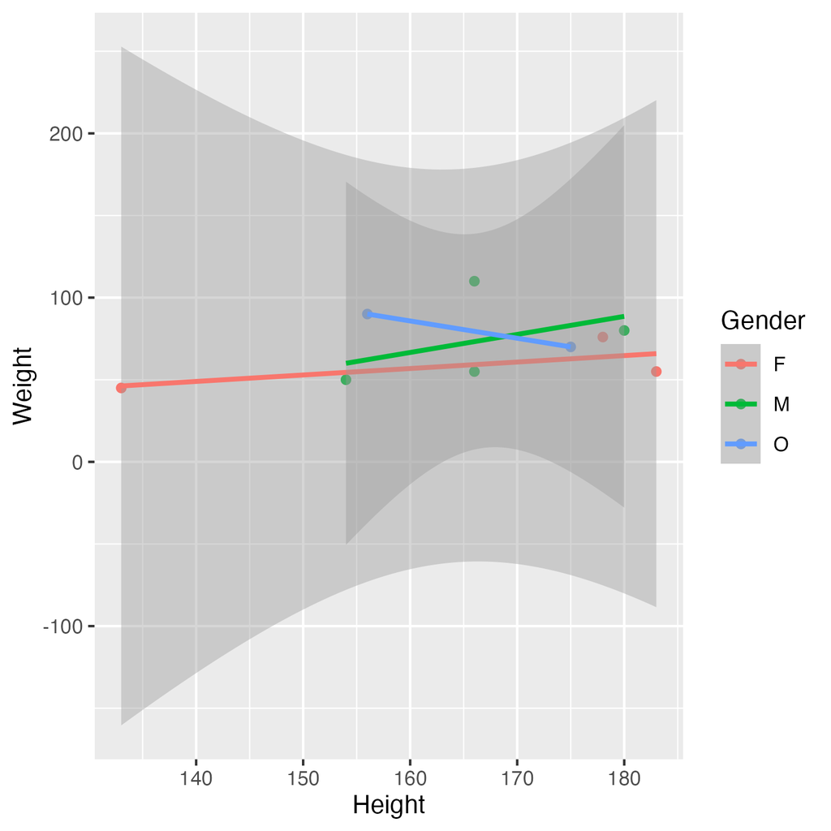

Figure 1: Height and Weight stratified by Gender.

### 2.2.3 Height by Stress Level

Figure 2 shows the distribution of height across stress levels with individuals reporting high stress levels appear to have a higher range and median of height compared to those reporting lower and medium stress levels.

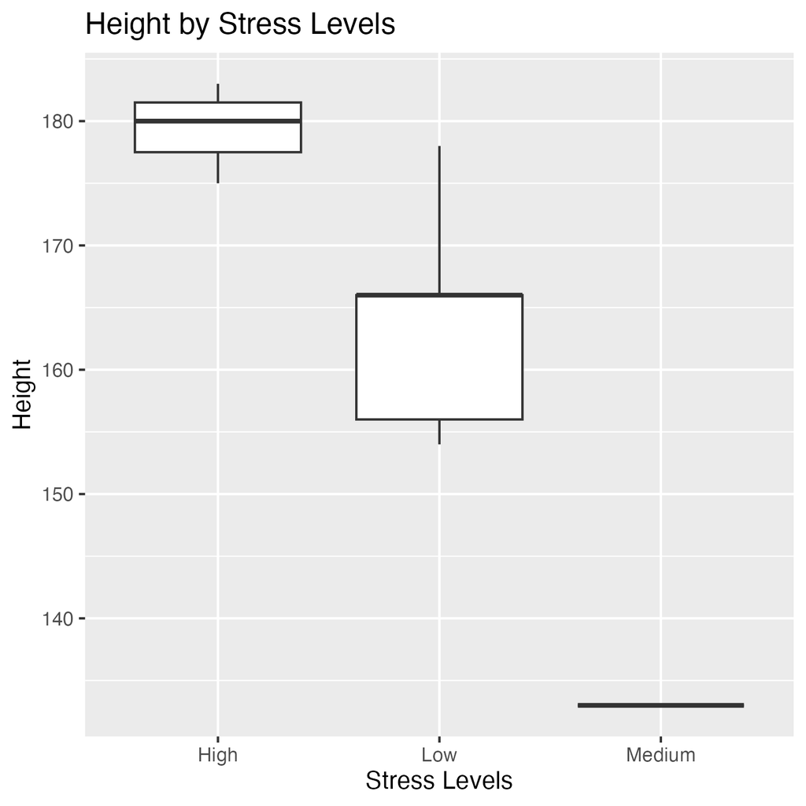

Figure 2: Height by Stress Level.

### 2.2.4 Height versus Weight

Figure 3 shows scatterplot with a positive trend between the variables of height and weight, with a few outliers within the dataset.

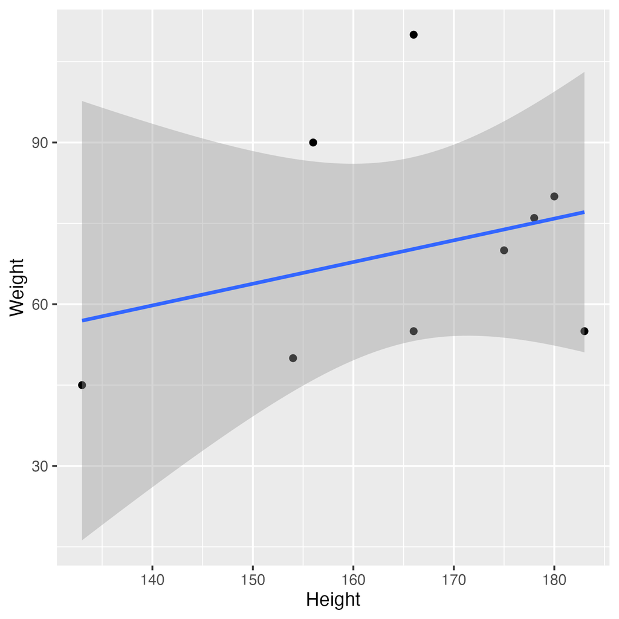

Figure 3: Scatterplot of Height vs Weight.

### 2.2.5 Weight Distribution versus Daily Steps

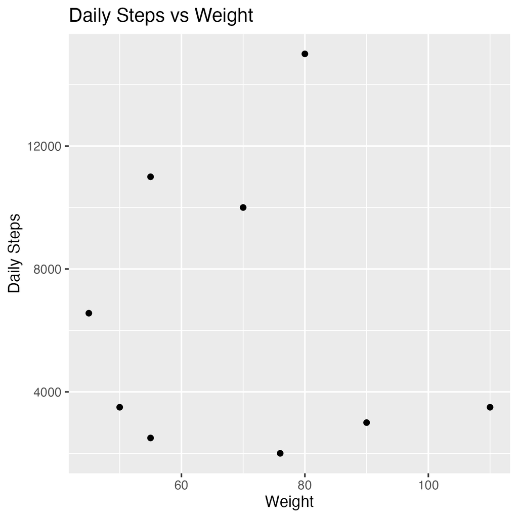

Figure 4: Scatterplot of Weight vs Daily Steps.

## 2.3 Full analysis

The estimated association between daily steps and height was small and not statistically significant (estimate = −0.0008, p = 0.75), suggesting no statistical meaningful relationship between step count and height in this dataset. Participants with low stress levels were estimated to be approximately 22 cm shorter on average, though this difference was not statistically significant (p = 0.34). Participants with medium stress levels were estimated to be approximately 50 cm shorter and this difference was statistically significant (p = 0.02).

Table 1: Linear model results predicting Height from Daily Steps and Stress Levels

| term | estimate | std.error | statistic | p.value |
| --- | --- | --- | --- | --- |
| (Intercept) | 188.5053079 | 27.2810468 | 6.9097535 | 0.0009731 |
| `Daily Steps` | -0.0007643 | 0.0022332 | -0.3422579 | 0.7460744 |
| `Stress Levels`Low | -22.2887473 | 21.3248430 | -1.0452010 | 0.3438044 |
| `Stress Levels`Medium | -50.4912951 | 15.8741171 | -3.1807309 | 0.0245181 |